# Actividad ACP

2024-02-23

## **Objetivo**

El objetivo es estudiar la relación calidad precio de 35 marcas de whisky, utilizando las variables

- **precio** (francos franceses)
- **proporción de malta ( %)**
- **vejez** (añejamiento en años)
- **apreciación** (nota promedio de un panel de catadores redondeada a entero).

Se dispone además de una variable categórica “categorías”, que clasifica las marcas según su contenido de malta (1=Bajo, 2=Estándar, 3=Puro malta).

Para obtener los datos use:

```r
library(FactoClass)
data("Whisky")
head(Whisky)
```

```
##   price malt type aging taste
## 1    70   20  low   5.0     3
## 2    60   20  low   5.0     2
## 3    65   20  low   7.5     2
## 4    74   25  low  12.0     2
## 5    70   25  low  12.0     3
## 6    73   30  low   5.0     0
```

```r
Y=Whisky[,-3]
```

**Trabajo**

Realice primero un ACP no normado y luego un ACP normado utilizando el software R y responda a las preguntas.

Para el ACP no normado utilice:

```r
library(FactoMineR)
library(factoextra)
```

```r
acpc <- PCA(Y, scale.unit = F)
```

[figure not shown]

[figure not shown]

```r
get_eigenvalue(acpc)
```

```
##       eigenvalue variance.percent cumulative.variance.percent
## Dim.1 953.238889       84.4467052                    84.44671
## Dim.2 169.350357       15.0026188                    99.44932
## Dim.3   4.980882        0.4412525                    99.89058
## Dim.4   1.235178        0.1094234                   100.00000
```

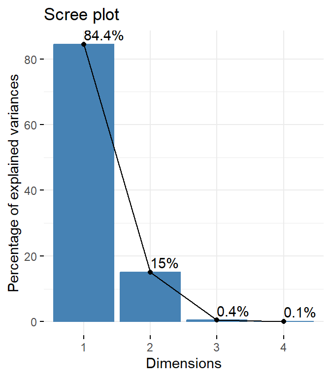

```r
fviz_eig(acpc, addlabels=T)
```

### Pregunta 1

En el ACP no normado, analice la contribución de las variables a la inercia(varianza). ¿Realmente se puede considerar un análisis de las cuatro variables?

### Pregunta 2

Realice el ACP normado, justifique por qué es el que conviene para los objetivos de este taller.

### Pregunta 3

¿Cuántos ejes retiene para el análisis? ¿Por qué?

### Pregunta 4

¿Cuál es la variable que más contribuye al primer eje? ¿Cuál es la que menos? (indique los porcentajes).

### Pregunta 5

Según el círculo de correlaciones, ¿cuáles son las variables más correlacionadas? ¿Cuánto es la correlación? ¿Si corresponden a lo que se observa en la matriz de correlaciones?

### Pregunta 6

¿Cuál es la variable mejor representada en el primer plano factorial? ¿Cuál la peor? (escriba los porcentajes).

### Pregunta 7

¿Qué representa el primer eje? ¿Qué nombre le asignaría? ¿Qué representa el segundo eje?

### Pregunta 8

¿Cuál es el individuo mejor representado en el primer plano factorial? Ubique sobre el gráfico de individuos al peor representado sobre el primer plano factorial (indique los porcentajes).

### Pregunta 9

¿Qué características tienen las marcas de Whisky según sus ubicaciones en el plano? (a la derecha, a la izquierda, arriba, abajo).

### Pregunta 11

Supongamos que usted desea comprar una botella de Whisky con buena apreciación y que no sea tan cara. Dé dos números de marcas que compraría. ¿Por qué? ?Cuáles son las características de las dos marcas?

### Pregunta 12

Seleccione dos marcas que definitivamente no compraría. ¿Por qué? ¿Qué características tienen?